# COMPSCIX 415.2 Homework 2

## **3.5.1 Exercises**

**4. Take the first faceted plot in this section:**  
**`ggplot(data = mpg) + geom_point(mapping = aes(x = displ, y = hwy)) + facet_wrap(~ class, nrow = 2)`**  
**What are the advantages to using faceting instead of the colour aesthetic? What are the disadvantages? How might the balance change if you had a larger dataset?**

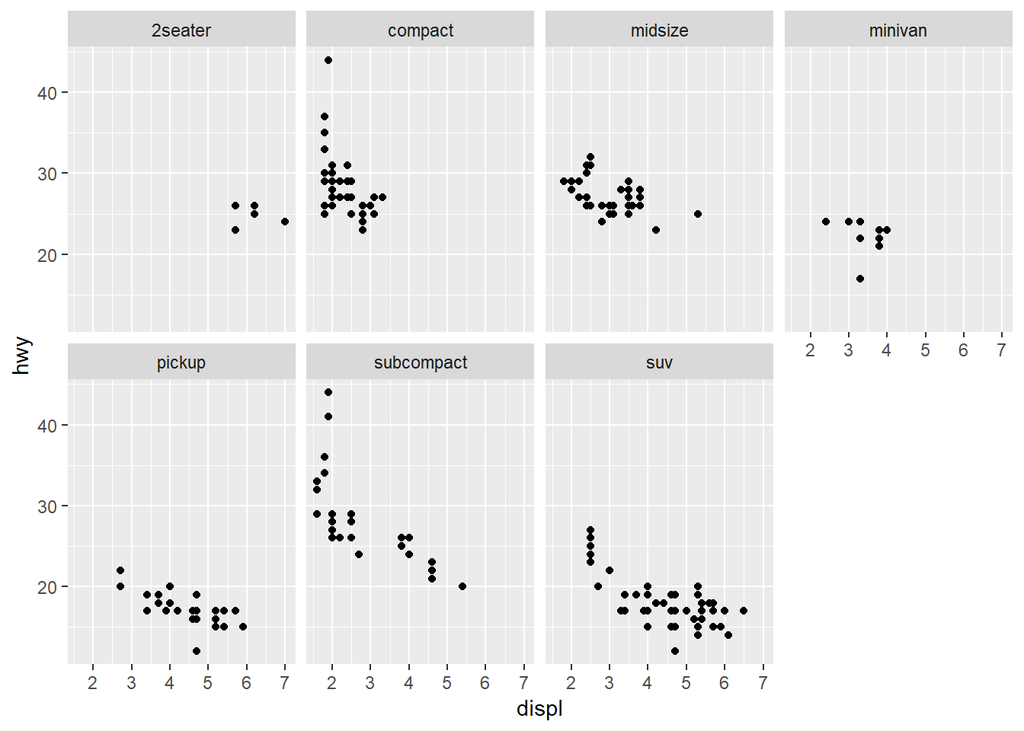

```r
ggplot(data = mpg) + geom_point(mapping = aes(x = displ, y = hwy)) + facet_wrap(~ class, nrow = 2)
```

Faceting allows you to split the dataset into smaller sections of interest and only show that data of that subsection for specific analysis, while using a color key shows all datasets in one plot where points may overlap, potentially making the plot harder to read.  
However, faceting also makes it harder to compare the sections of data by the variable it is split by, since the plots are split up and the axes are separate. Using the color aesthetic allows you to compare the each `class` relative to each other in the same coordinate plot.  
When the dataset is smaller, using a color key over faceting *may* be more beneficial since the smaller dataset can be spread over the plot more sparsely where each point (and its color) is more visible.  
When the dataset is larger, using faceting to cluster the data by the chosen variable (in this example `class`) *may* help with viewing and with organizing the target data into more readable plots.

**5. Read `?facet_wrap`. What does `nrow` do? What does `ncol` do? What other options control the layout of the individual panels? Why doesn’t `facet_grid()` have `nrow` and `ncol` arguments?**

`nrow` splits the subplots into the specified number of rows. `ncol` splits the subplots into the specified number of columns.  
`facets` is the set of variables chosen to group the subplots by; depending on the variables chosen, this will change the layout and subplots displayed. `as.table` controls the tabular layout of the facets where if set to `TRUE`, the highest values are placed at the bottom-right and if set to `FALSE`, the highest values are placed at the top-right.  
`facet_grid()` does not have `nrow` and `ncol` arguments because it automatically forms a matrix of panels (row x col) out of the chosen two variables (works best with discrete variables).

## **3.6.1 Exercises**

**1. What geom would you use to draw a line chart? A boxplot? A histogram? An area chart?**  
`geom_line()` connects the observations in order of the variable on the x axis.  
`geom_boxplot()` shows the five summary statistics as boxplots.  
`geom_histogram()` creates bars by frequency of the variable.  
`geom_area()` creates area charts of the variable where ymin is fixed to 0.

**2. Run this code in your head and predict what the output will look like. Then, run the code in R and check your predictions.**  
**`ggplot(data = mpg, mapping = aes(x = displ, y = hwy, color = drv)) + geom_point() + geom_smooth(se = FALSE)`**

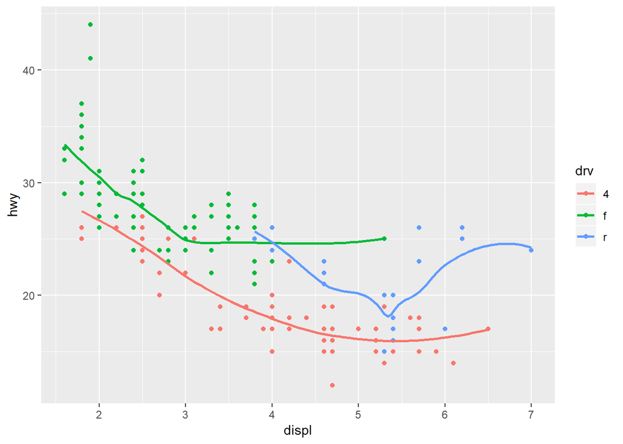

```r
ggplot(data = mpg, mapping = aes(x = displ, y = hwy, color = drv)) + geom_point() + geom_smooth(se = FALSE)
```

This code will plot displ on the x axis and hwy on the y axis with drv as a categorical color scale. The plot will include scatterpoints (which will follow the color scale) and smooth lines trending with displ vs hwy per drv, where the number of lines is the number of categorical colors.

**3. What does `show.legend = FALSE` do? What happens if you remove it? Why do you think I used it earlier in the chapter?**

Setting `show.legend = FALSE` hides the legend from the `geom` plot. Depending on the `geom` plot type and the `aes` mapping arguments, removing `show.legend = FALSE` may or may not affect the plot. For example, argument `group` does not show a legend, but argument `color` does. `show.legend = FALSE` was used earlier in the chapter to demonstrate that `color` displays a legend and must be hidden purposefully with the code snippet, unlike `group`.

**4. What does the `se` argument to geom_smooth() do?**

`se` displays the confidence interval around the line if set to `TRUE` and hides the confidence interval if set to `FALSE`.

**5. Will these two graphs look different? Why/why not?**  
**`ggplot(data = mpg, mapping = aes(x = displ, y = hwy)) + geom_point() + geom_smooth()`**  
**`ggplot() + geom_point(data = mpg, mapping = aes(x = displ, y = hwy)) + geom_smooth(data = mpg, mapping = aes(x = displ, y = hwy))`**

The two plots will look the same. The first version sets the data and mapping in `ggplot()` where the arguments will be shared for `geom_smooth()` and `geom_point()`. The second version declares the exact same arguments as version one, only locally in `geom_smooth()` and locally for `geom_point()`.

**6. Recreate the R code necessary to generate the following graphs.**

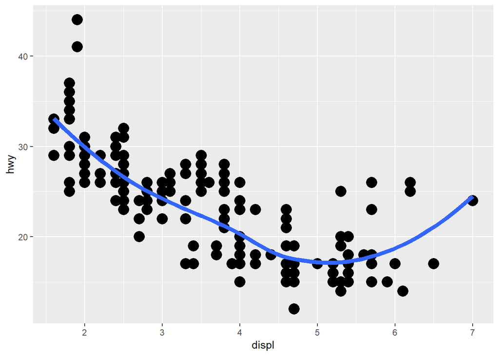

```r
mpgPlot <- ggplot(data = mpg, aes(x = displ, y = hwy), size = 5)
mpgPlot + geom_point(size = 5, show.legend = FALSE) + geom_smooth(se = FALSE, size = 2)
```

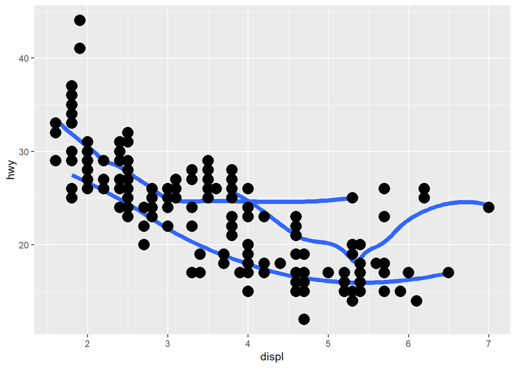

```r
mpgPlot + geom_smooth(se = FALSE, aes(group = drv), size = 2) + geom_point(size = 5, show.legend = FALSE)
```

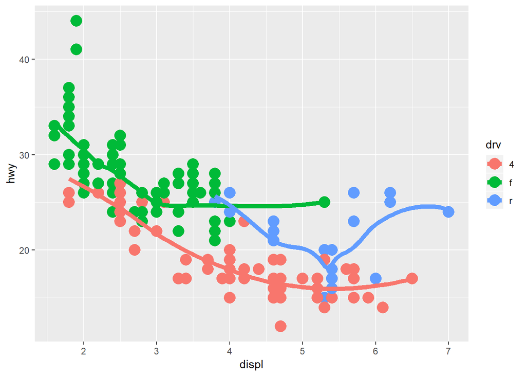

```r
mpgPlot + geom_point(aes(color = drv), size = 5) + geom_smooth(se = FALSE, aes(color = drv), size = 2)
```

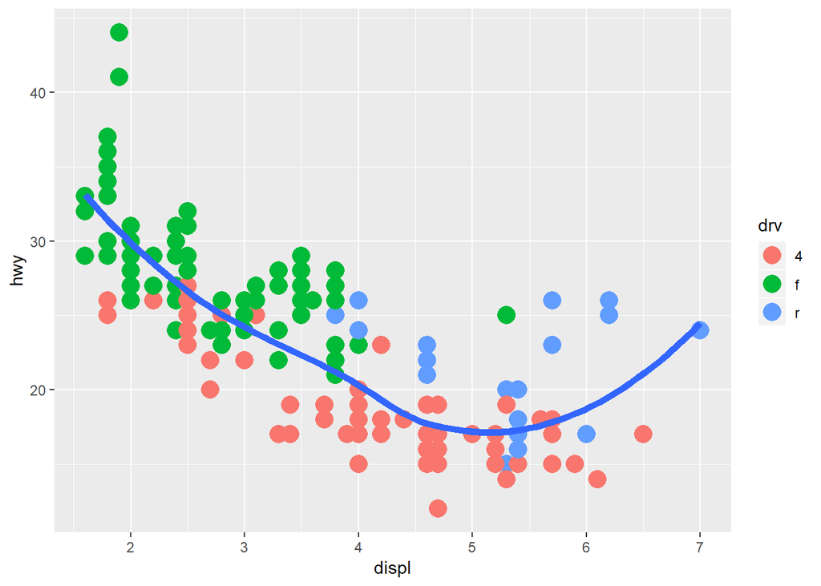

```r
mpgPlot + geom_point(aes(color = drv), size = 5) + geom_smooth(se = FALSE, size = 2)
```

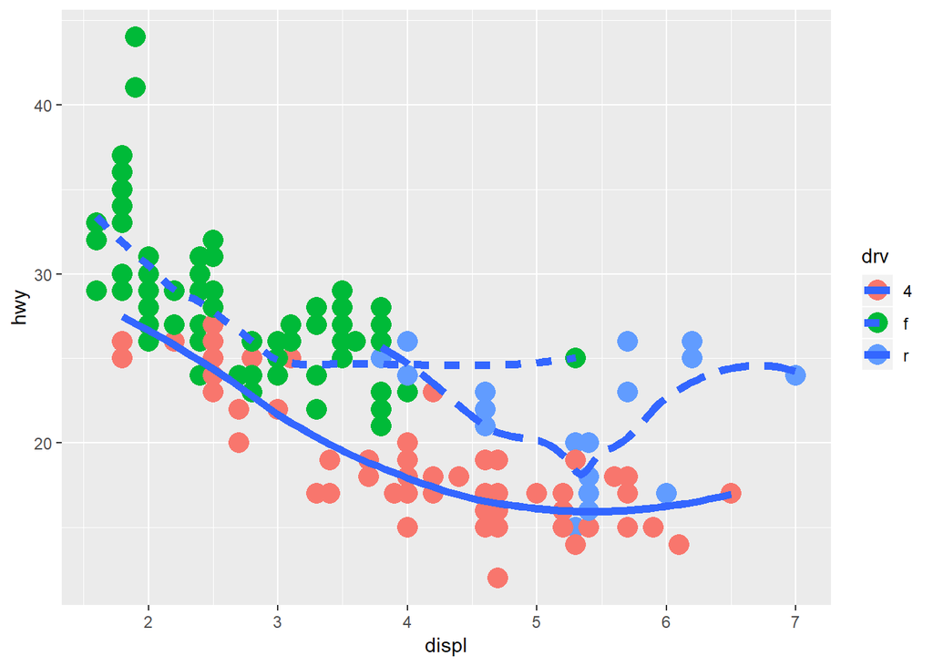

```r
mpgPlot + geom_point(aes(color = drv), size = 5) + geom_smooth(se = FALSE, aes(linetype = drv), size = 2)
```

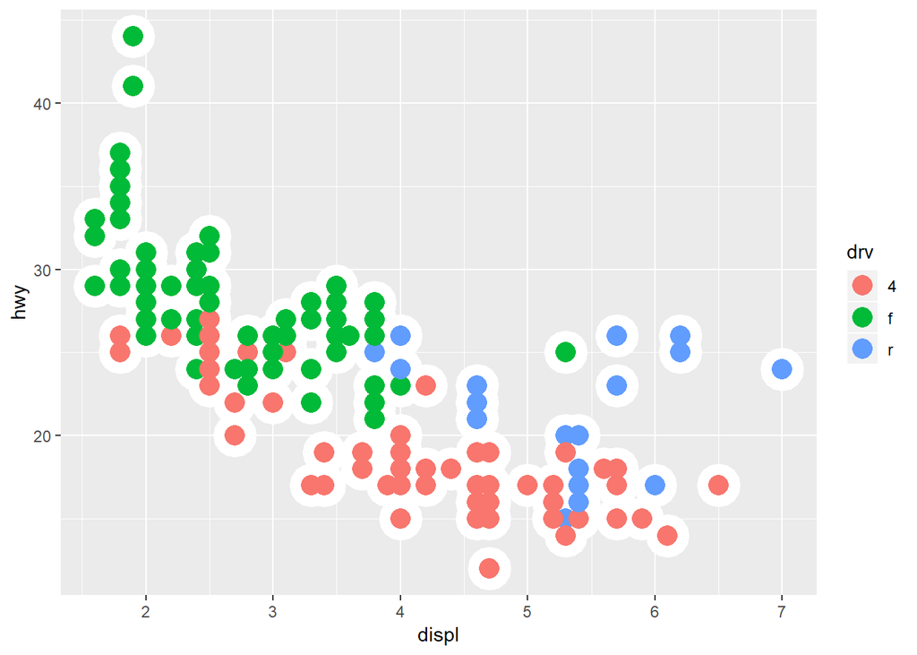

```r
mpgPlot + geom_point(aes(color = drv), shape = 21, size = 5, color = "white", stroke = 5) + geom_point(aes(color = drv), size = 5)
```

## **3.7.1 Exercises**

**2. What does geom_col() do? How is it different to geom_bar()?**

`geom_col` is used when the height of the bars represents the values in the data and uses `stat_identity()`; it needs x and y variables.  
`geom_bar` is used to report the frequency of the variable chosen (only needs x variable); therefore the height of the bars vary proportionally to the different groups of the x variable.

## **What is a Data Scientist data graphics analysis.**

**Link to data graphics: https://static.guim.co.uk/sys-images/Guardian/Pix/pictures/2012/3/2/1330695817953/EMC2-graphic-on-data-scie-008.jpg**

The first noticeable issue is the chosen color scheme. Using shades of blue and gray can be difficult to distinguish. This can be improved by using a more primary color scheme instead.

The first visualization for: **Over the next five years, demand for data scientists will…** uses a circle graph, which is hard to compare values because each value is relative to the previous value. The position of the dataset is dependent on the position of the adjacent set. It would be better to use an absolute position to compare each dataset (a bar graph would solve this). Another issue with using the circle graph is having to read the description of each dataset in no particular order. Using a bar graph can order the datasets, making it easier to read. From left to right: Significantly less, less than, met, somewhat outpace, significantly outpace. A good feature about the graph is the value labels are clear which compensates for the relative positioning of the circle graph datasets.

The second visualization about **the best source of data science talent** uses area graphs, when it could have just used a simple bar graph to make it easier to read.

The third visualization for: **The biggest obstacle to data science adoption in our organization is:** could have used a bar graph as well, rather than using lighter shades to represent lower percentage votes in the survey.

The fourth visualization for **comparing degrees between data scientists and business intelligence professionals** is difficult to understand at first glance. Since the visualizations are split by degree, does each percentage represent part of the whole for all data scientists vs BI professionals? If so, they should be combined into one graph, sharing the same y-axis scale. Another misleading feature is for the earlier degrees, it looks like less data scientists received, for example, high school degrees than degrees BI professionals received. This isn’t what the visualization was trying to represent. Instead, from left to right, the percentages should be cascading downwards: people who received masters degrees also received college graduate, some college, and high school. Instead of reporting just the percentage of high school degrees for data scientists and BI professionals, the data should have been inclusive of any dependent degrees. OR the question could have been phrased: What was the highest degree obtained? In that case, the graph would make slightly more sense.

The fifth visualization about **comparing background studies of data scientists vs BI professionals** uses the area of circles to represent each study type. A bar graph would have been sufficient and easier to read and on the same y-axis scale for comparison purposes. It is much harder to use areas to compare instead of length of bars to compare.

The sixth visualization about **thoughts on new technology creating demand** uses a circle graph, which is okay in this case since it is only comparing two values. The color scheme could use improvement though since the shades of blue are not contrasting enough.

The seventh visualization about **the characteristics of data scientists** is extremely hard to understand. It lists the characteristics of big data vs. normal data science (maybe the answer options it offered in the survey), but understanding how that translates to the graph below took some inference. Depending on what the user chose, they would lean more towards big data or more towards normal data. The graph could have plotted the frequency of the votes for each comparison category. Each of the five classes could have two bars representing the vote count.

The eighth visualization about the **data lifecycle** is okay, but the colors representing BI and Data Scientists *switched* which could be very misleading.

The last visualization about **who data scientists work with** is probably one of the worst graphs in the report. It might as well have used a table to report the numbers because each block reports a different number, but the area/bar length is the same for each team. The color scale doesn’t seem to trend with the values either. A bar graph representation would have been the easiest way to fix all problems about this visualization.